# Midterm Home Price Predictions

Alex Abramson and Shuyan Hong

November 11, 2018

# Introduction

This project aims to predict prices of home sales based on observable characteristics of the home. Improving our ability to predict home prices would allow a variety of end users, from private homebuyers and homesellers to housing affordability advocates, to make better decisions and more efficiently allocate resources. Obviously, predicting prices is difficult because sale price is affected by many intangible and hard to observe characteristics. Additionally there is a tradeoff between generalizability and accuracy; a model targeted towards a broader range of areas is more widely applicable, yet likely less incisive, than one narrowly targeted toward a particular market. Our modeling strategy only aims to predict in one market, Nashville, and centers around attributes of the home, attributes of the neighborhood, and comparable sales nearby. Ultimately, our model identifies several useful predictors, including some specific to Nashville; however, our model’s predictions are typically off by roughly 100 thousand dollars, and we see room for further improvements.

# Data

We utilized several different sources of data. First and most important are listings of extant home sales and the characteristics of the homes, sourced from provided data. These included the square footage, acrage, type of home, season of sale, year built, floor height and location. Second were spatial characteristics, such as proximity to amenities and disamenities. These included 1) distance to different types of crimes, such as robberies, assaults, and drug crimes, 2) distance to police stations, 3) distance to property code violations, and 4) distance to major employment centers such as the central business district (CBD) and Vanderbilt University. This data was sourced from Nashville’s OpenData portal or constructed manually. Finally, we used the spatial characteristics of the original home sale dataset to create predictors measuring spatial autocorrelation, i.e. proximity to other sales of the same housing stock type and their sale prices and prices per square foot. This last set of predictors essentially mimics the real estate valuation technique of comparable sale comparison, which is the standard in the industry.

## Summary Statistics and Correlation Matrix

Below are the Summary Statistics and a Correlation Matrix of our most significant and/or interesting variables. While our model contains many more variables than those listed here, we felt that the variables selected below were the most interesting, significant, and worth focusing on. This selection contains a sampling of important variables related to the internal characteristics, locational amenities, and spatial structure of the sales.

| **Internal Characteristics** |  |  |  |  |  |  |  |
| --- | --- | --- | --- | --- | --- | --- | --- |
| Acrage | Min. : 0.0000 | 1st Qu.: 0.0000 | Median : 0.1600 | Mean : 0.2304 | 3rd Qu.: 0.2700 | Max. :47.9700 | NA |
| sf_finished_less_ifla | Min. : 0 | 1st Qu.: 1102 | Median : 1556 | Mean : 1665 | 3rd Qu.: 2150 | Max. :10608 | NA |
| sf_bsmt_fin | Min. : 0.0 | 1st Qu.: 0.0 | Median : 0.0 | Mean : 55.7 | 3rd Qu.: 0.0 | Max. :2600.0 | NA |
| **Amenities/Public Services** |  |  |  |  |  |  |  |
| distToCBD | Min. : 652.7 | 1st Qu.: 4838.9 | Median : 7528.3 | Mean : 8802.7 | 3rd Qu.:12714.5 | Max. :23542.6 | NA |
| distToVanderbilt | Min. : 552.8 | 1st Qu.: 4759.0 | Median : 8182.4 | Mean : 9021.5 | 3rd Qu.:12620.3 | Max. :23989.6 | NA |
| d_Police | Min. :0.0006925 | 1st Qu.:0.0201241 | Median :0.0318283 | Mean :0.0380275 | 3rd Qu.:0.0520340 | Max. :0.1256367 | NA |
| d_PropViol | Min. :0.00003973 | 1st Qu.:0.00044700 | Median :0.00083477 | Mean :0.00113160 | 3rd Qu.:0.00144728 | Max. :0.00883368 | NA |
| d_crime | Min. :0.000009095 | 1st Qu.:0.000565079 | Median :0.000844717 | Mean :0.000995897 | 3rd Qu.:0.001263932 | Max. :0.005999697 | NA |
| **Spatial Structure** |  |  |  |  |  |  |  |
| avgNearSameTypeSalePrice | Min. : 0 | 1st Qu.: 143125 | Median : 215000 | Mean : 283051 | 3rd Qu.: 349850 | Max. :5419479 | NA’s :633 |
| avgNearSameTypeSalePrice15 | Min. : 23457 | 1st Qu.: 150002 | Median : 227250 | Mean : 284676 | 3rd Qu.: 351942 | Max. :2713221 | NA’s :633 |
| avgNearSameTypeSalePricePerSF | Min. : 0.00 | 1st Qu.: 95.08 | Median : 133.09 | Mean : 155.77 | 3rd Qu.: 185.70 | Max. :2603.61 | NA’s :633 |
| avgNearSameTypeSalePricePerSF15 | Min. : 22.45 | 1st Qu.: 98.93 | Median : 138.42 | Mean : 156.54 | 3rd Qu.: 186.15 | Max. :1379.69 | NA’s :633 |

|  | Acrage | SF | BtSF | D_CBD | D_Vbilt | D_Pol | D_Viol | D_Crim | ANNP5 | ANNP15 | ANNPSF5 | ANNPSF15 |
| --- | --- | --- | --- | --- | --- | --- | --- | --- | --- | --- | --- | --- |
| Acrage | 1.00 | 0.18 | 0.19 | 0.14 | 0.15 | 0.13 | 0.18 | 0.28 | -0.01 | -0.02 | -0.12 | -0.15 |
| sf_finished_less_ifla | 0.18 | 1.00 | 0.29 | -0.17 | -0.27 | -0.06 | 0.30 | 0.34 | 0.41 | 0.42 | 0.07 | 0.09 |
| sf_bsmt_fin | 0.19 | 0.29 | 1.00 | 0.02 | 0.01 | 0.05 | 0.07 | 0.13 | 0.03 | 0.02 | -0.03 | -0.03 |
| distToCBD | 0.14 | -0.17 | 0.02 | 1.00 | 0.92 | 0.77 | 0.24 | 0.13 | -0.25 | -0.30 | -0.31 | -0.38 |
| distToVanderbilt | 0.15 | -0.27 | 0.01 | 0.92 | 1.00 | 0.69 | 0.09 | 0.01 | -0.37 | -0.44 | -0.37 | -0.45 |
| d_Police | 0.13 | -0.06 | 0.05 | 0.77 | 0.69 | 1.00 | 0.36 | 0.24 | -0.12 | -0.15 | -0.20 | -0.25 |
| d_PropViol | 0.18 | 0.30 | 0.07 | 0.24 | 0.09 | 0.36 | 1.00 | 0.49 | 0.20 | 0.22 | 0.03 | 0.02 |
| d_crime | 0.28 | 0.34 | 0.13 | 0.13 | 0.01 | 0.24 | 0.49 | 1.00 | 0.19 | 0.21 | -0.02 | -0.02 |
| avgNearSameTypeSalePrice | -0.01 | 0.41 | 0.03 | -0.25 | -0.37 | -0.12 | 0.20 | 0.19 | 1.00 | 0.87 | 0.80 | 0.69 |
| avgNearSameTypeSalePrice15 | -0.02 | 0.42 | 0.02 | -0.30 | -0.44 | -0.15 | 0.22 | 0.21 | 0.87 | 1.00 | 0.70 | 0.81 |
| avgNearSameTypeSalePricePerSF | -0.12 | 0.07 | -0.03 | -0.31 | -0.37 | -0.20 | 0.03 | -0.02 | 0.80 | 0.70 | 1.00 | 0.85 |
| avgNearSameTypeSalePricePerSF15 | -0.15 | 0.09 | -0.03 | -0.38 | -0.45 | -0.25 | 0.02 | -0.02 | 0.69 | 0.81 | 0.85 | 1.00 |

## Sale Prices

Below are two maps of sales in the Nashville area, colored by sale price and by count of sales. It is evident that while sales are concentrated in the southeastern suburban boundary, in a couple pockets of North and East Nashville, and to a lesser extent in near South Nashville, the highest sale prices are located in the far south Nashville neighborhoods of Green Hills and Belle Meade. Sales are shown aggregated to tract level for ease of interpretation.

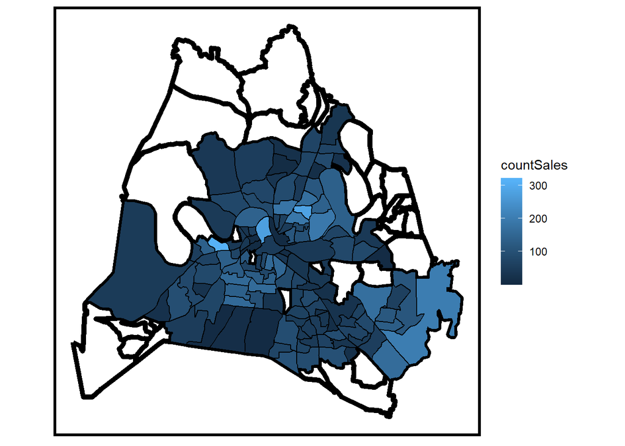

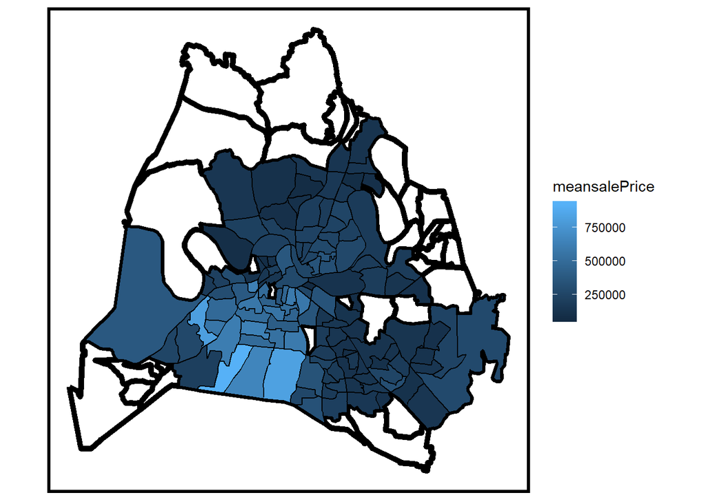

## Interesting Predictors

Following are maps of a few interesting spatial predictors

### Year Constructed

Below are maps of sales colored by the percentage of sold housing units that were built in each decade since the 1930s. East and near South Nashville have a prepondereance of older housing stock (30’s and earlier). Clearly, the 40s, 50s, and 60s saw extensive suburbanization, including an extensive period of building in the now poorer southeast Nashville, while the 80s saw a shift towards building in the now richer south-southwest Nashville. The 90s saw building only on the exurban edge of southeast Nashville, while the 2000s have seen a shift towards the exurbs and a return to the favored southern Nashville.

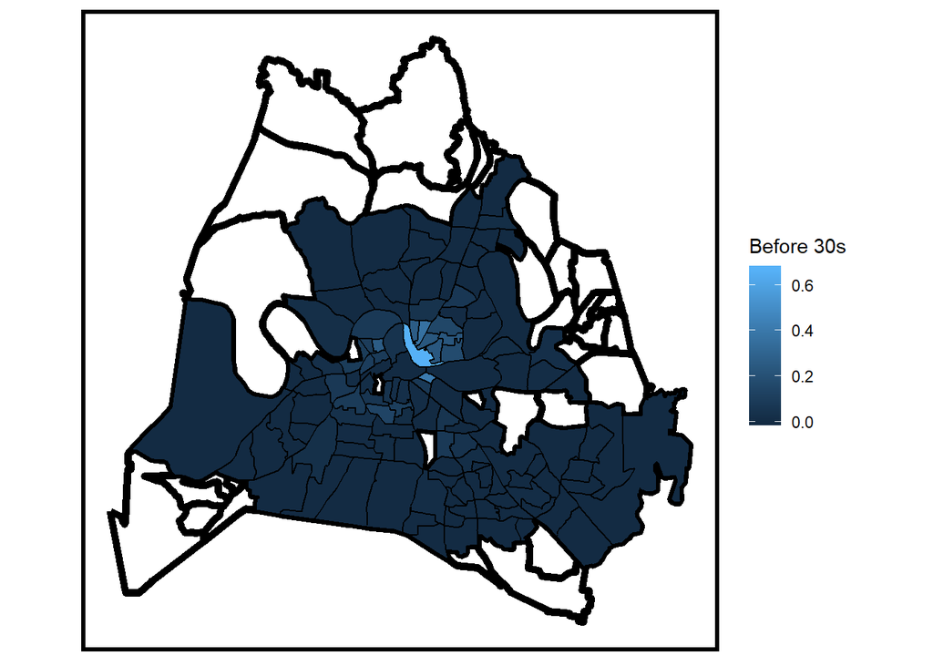

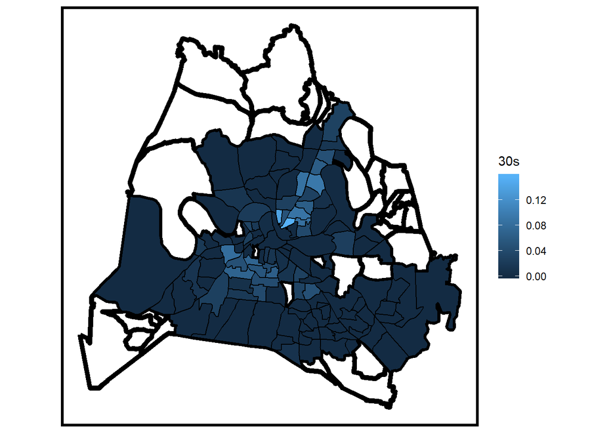

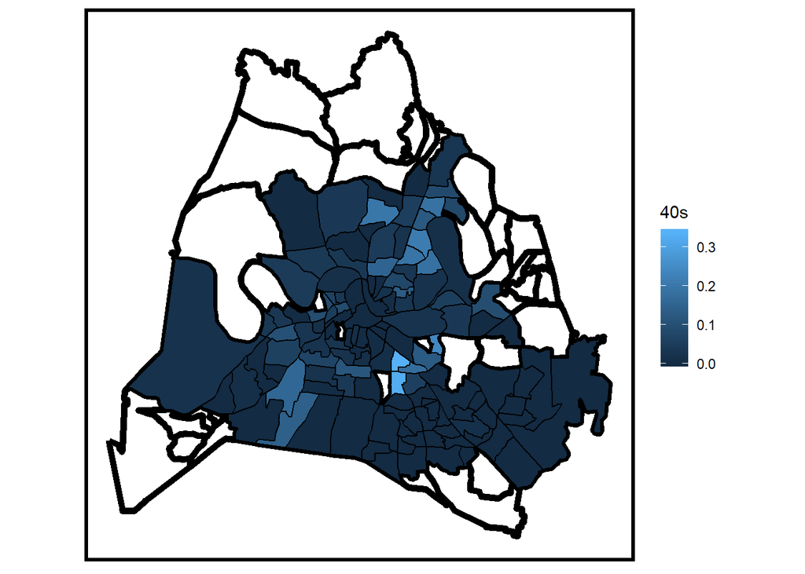

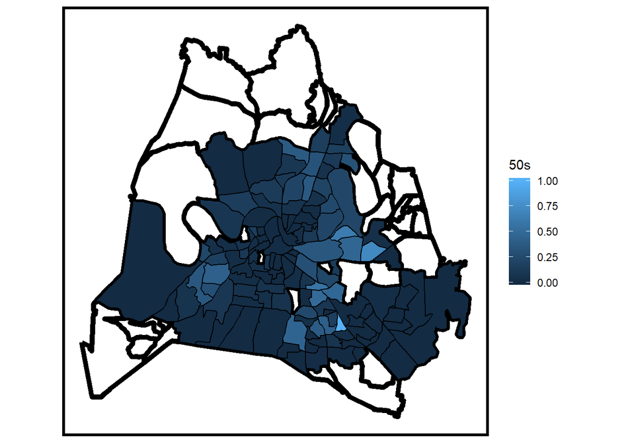

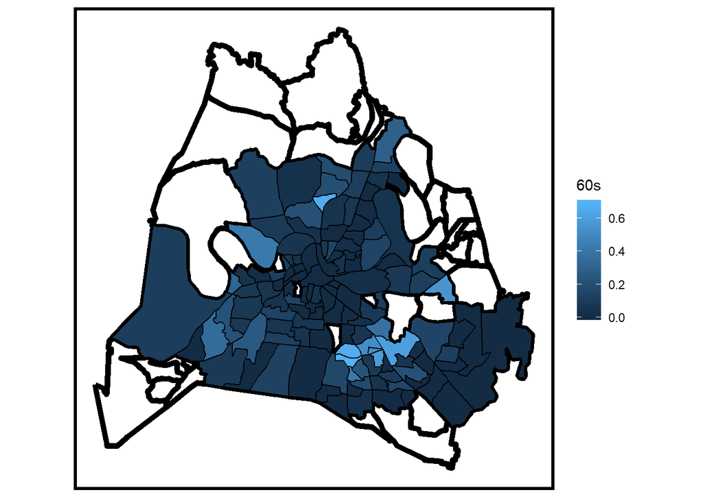

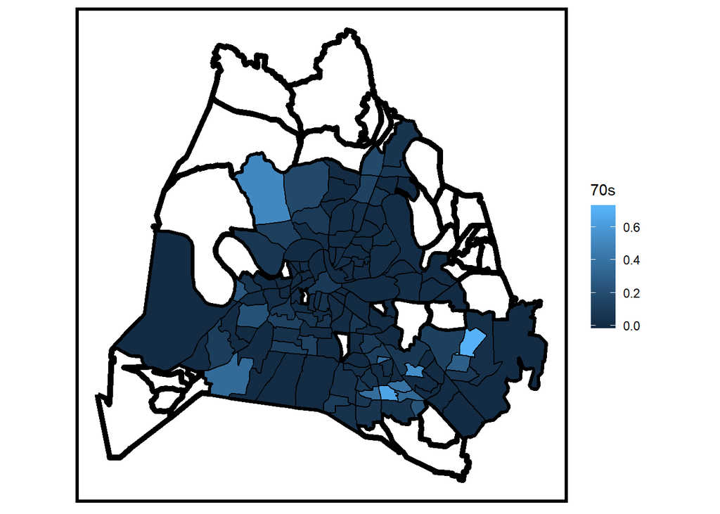

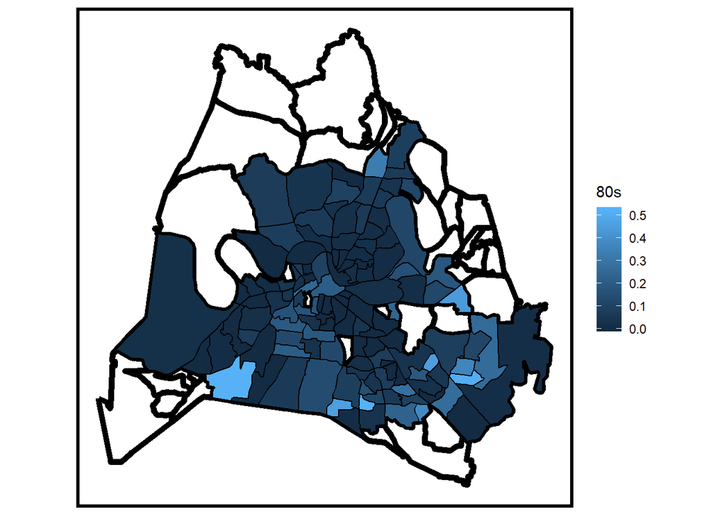

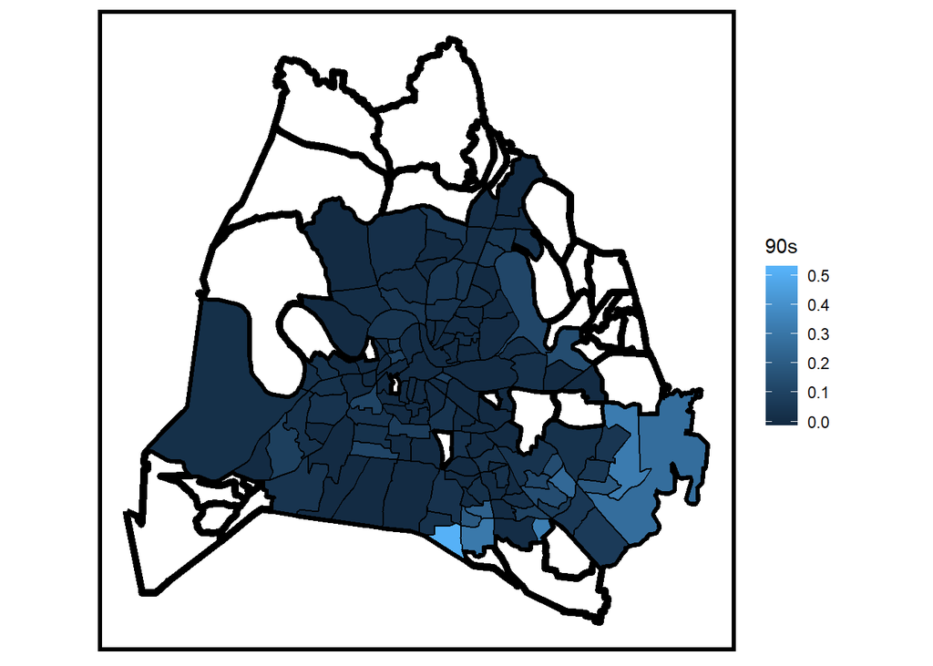

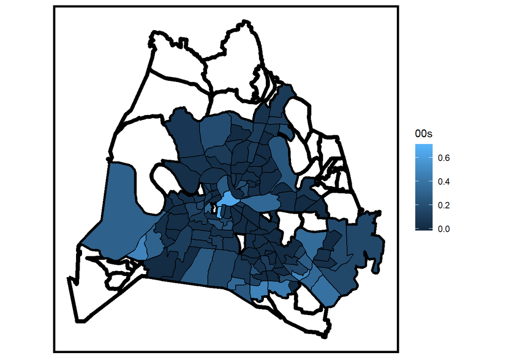

### Distance to crime and property violations

Below are maps displaying mean distance to the nearest five crimes and property violations respectively by tract. Both tell a similar story. In both maps, it is plainly evident that the southern Nashville neighborhoods possess the fewest crimes and violations, and houses sold here are on average farther from both of these disamenities.

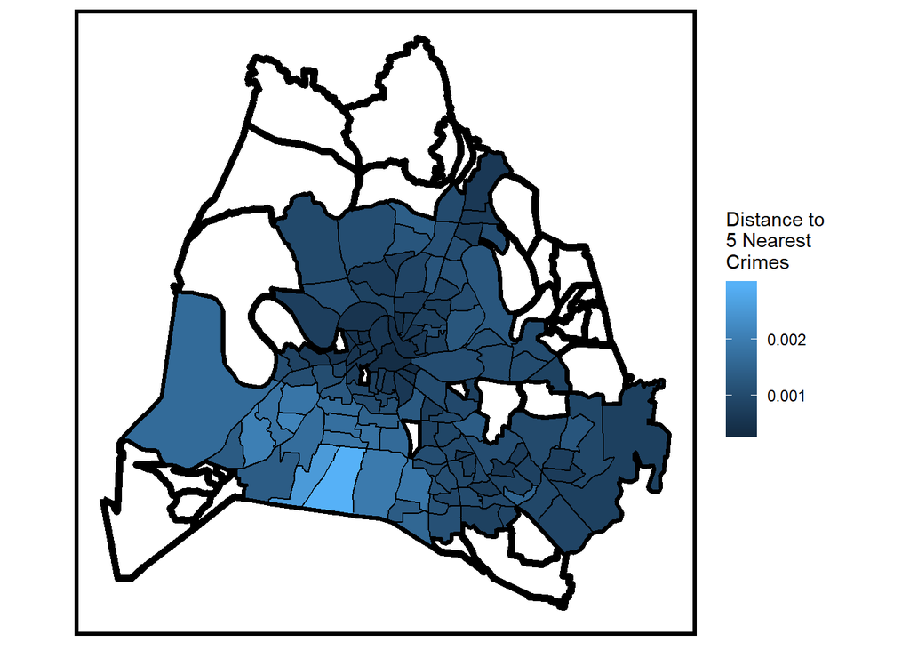

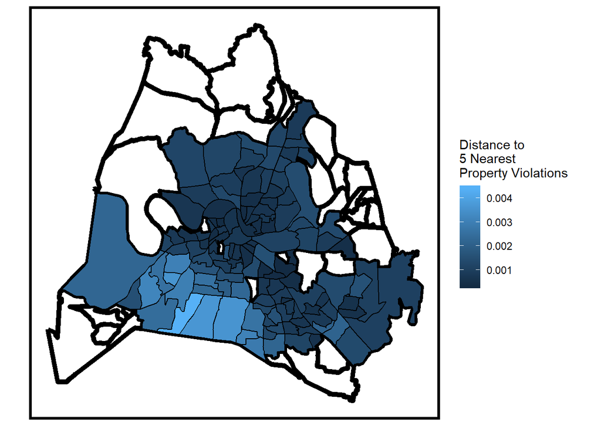

# Methods

Our method is to divide our dataset of home sales into two subsets: a training set and a test set. Using only data from the training set, we fit an ordinary least squares (OLS) model which best explains sale price as a function of our independent variables. In short, this model is the best possible equation by which we can plug in values for known characteristics and receive a price estimate in return.

We then test this model on the test set of data to see how well it works on new data. This step is crucial to assure that we avoid overfitting, i.e. the problem of finding spurious relationships between individual characteristics and sale prices that are quirks of the particular sample that we train our model on. To be especially sure we have not overfit, we repeat this process of subdividing and testing 99 more times. Only then do we measure the accuracy of our model, by taking the average accuracy (R Squared, MAE, or MAPE) of each of the 100 tests.

# Results

## Polished Table of In Sample Training Set Model Results

Below are the coefficients derived for all of the variables in our model. Since we are reporting the results of our model derived from and applied to only our training set, we do not report our goodness of fit metrics (since to do so would violate the cardinal law of not testing a model on the same dataset it is trained on). Our model includes many variables which are not all that significant, and some of which are collinear with one another. Since this model’s purpose is to maximize predictive accuracy rather than isolate causal relationships between any one variable and sale price, we are less concerned with the possiblity that some of the variables are presented as having falsely low p-values due to collinearity. That said, there are some strikingly powerful predictors, most noticeably variations on the average sale prices of nearest neighboring sales. Their clear significance is even more striking given the multicollinearity present in this model.

|  | Estimate | Std. Error | t value | Pr(>\|t\|) |
| --- | --- | --- | --- | --- |
| (Intercept) | -36942.918 | 631883.899 | -0.058 | 0.953 |
| Acrage | 40552.165 | 12706.243 | 3.192 | 0.001 |
| sf_finished_less_ifla | 96.569 | 6.960 | 13.876 | 0.000 |
| baths | 5340.929 | 5328.596 | 1.002 | 0.316 |
| avgHtfl_buildingSTD | -8325.981 | 31012.233 | -0.268 | 0.788 |
| avgHtfl_buildingx | -6970.734 | 30065.765 | -0.232 | 0.817 |
| sf_bsmt | 11.412 | 8.674 | 1.316 | 0.188 |
| sf_bsmt_fin | -48.691 | 17.250 | -2.823 | 0.005 |
| ac_sfyi1 | -168227.967 | 20680.569 | -8.135 | 0.000 |
| effyearbuilt_building | 118.531 | 212.251 | 0.558 | 0.577 |
| yearbuilt_building | -83.994 | 298.794 | -0.281 | 0.779 |
| d_crime | -5730490.671 | 5731582.326 | -1.000 | 0.317 |
| d_crime_drug | -3253819.967 | 1938015.450 | -1.679 | 0.093 |
| d_crime_assault | -2268997.700 | 1359127.339 | -1.669 | 0.095 |
| d_crime_robbery | -207313.333 | 1197743.939 | -0.173 | 0.863 |
| d_OthSale | -11878166.934 | 4513573.707 | -2.632 | 0.009 |
| d_PropViol | 9117206.426 | 3939619.920 | 2.314 | 0.021 |
| distToCBD | 15.022 | 6.495 | 2.313 | 0.021 |
| distToVanderbilt | -15.573 | 6.493 | -2.399 | 0.016 |
| avgNearSalePrice | 0.342 | 0.025 | 13.906 | 0.000 |
| as.factor(LocationZip)37027 | -14266.112 | 29270.689 | -0.487 | 0.626 |
| as.factor(LocationZip)37115 | 60269.128 | 24307.828 | 2.479 | 0.013 |
| as.factor(LocationZip)37189 | 105644.094 | 125382.741 | 0.843 | 0.399 |
| as.factor(LocationZip)37201 | 67859.960 | 55247.813 | 1.228 | 0.219 |
| as.factor(LocationZip)37203 | -12259.915 | 29004.428 | -0.423 | 0.673 |
| as.factor(LocationZip)37204 | -14513.863 | 29200.988 | -0.497 | 0.619 |
| as.factor(LocationZip)37205 | -31516.614 | 30523.599 | -1.033 | 0.302 |
| as.factor(LocationZip)37206 | 51164.358 | 26949.265 | 1.899 | 0.058 |
| as.factor(LocationZip)37207 | 39841.647 | 25309.310 | 1.574 | 0.115 |
| as.factor(LocationZip)37208 | 11103.916 | 26078.887 | 0.426 | 0.670 |
| as.factor(LocationZip)37209 | -15028.389 | 26040.207 | -0.577 | 0.564 |
| as.factor(LocationZip)37210 | 33789.231 | 27624.183 | 1.223 | 0.221 |
| as.factor(LocationZip)37211 | 10894.375 | 16746.884 | 0.651 | 0.515 |
| as.factor(LocationZip)37212 | -14538.203 | 32426.011 | -0.448 | 0.654 |
| as.factor(LocationZip)37214 | 55772.400 | 23795.736 | 2.344 | 0.019 |
| as.factor(LocationZip)37215 | -23639.543 | 31347.844 | -0.754 | 0.451 |
| as.factor(LocationZip)37216 | 53420.000 | 25141.737 | 2.125 | 0.034 |
| as.factor(LocationZip)37217 | 21381.951 | 16201.948 | 1.320 | 0.187 |
| as.factor(LocationZip)37218 | 1827.041 | 29615.106 | 0.062 | 0.951 |
| as.factor(LocationZip)37219 | -231.364 | 85196.368 | -0.003 | 0.998 |
| as.factor(LocationZip)37220 | -14441.064 | 38428.946 | -0.376 | 0.707 |
| as.factor(LocationZip)37221 | -49323.778 | 37445.288 | -1.317 | 0.188 |
| avgNearSalePricePerSF | -72.262 | 34.064 | -2.121 | 0.034 |
| noBuildYear | 286689.301 | 636105.065 | 0.451 | 0.652 |
| earlierBuilt | 9809.117 | 20643.800 | 0.475 | 0.635 |
| d_Police | 73206.288 | 231479.279 | 0.316 | 0.752 |
| avgNearSameTypeSalePrice | 0.149 | 0.042 | 3.578 | 0.000 |
| avgNearSameTypeSalePricePerSF | 207.797 | 71.286 | 2.915 | 0.004 |
| avgNearSameTypeSalePrice15 | 0.187 | 0.048 | 3.909 | 0.000 |
| avgNearSameTypeSalePricePerSF15 | 295.736 | 96.822 | 3.054 | 0.002 |
| thirtiesBuilt | -5049.595 | 21569.813 | -0.234 | 0.815 |
| fortiesBuilt | -5189.612 | 15800.154 | -0.328 | 0.743 |
| fiftiesBuilt | -13682.508 | 12273.746 | -1.115 | 0.265 |
| sixtiesBuilt | -13199.745 | 12921.916 | -1.022 | 0.307 |
| seventiesBuilt | -9925.771 | 14526.938 | -0.683 | 0.494 |
| eightiesBuilt | -13491.784 | 14938.778 | -0.903 | 0.366 |
| ninetiesBuilt | -13335.405 | 17394.327 | -0.767 | 0.443 |
| twoThousandsBuilt | 7288.483 | 10251.144 | 0.711 | 0.477 |
| roomsunits_building | 3083.184 | 3133.173 | 0.984 | 0.325 |
| bedroomsunits_building | 2281.465 | 5730.905 | 0.398 | 0.691 |
| units_building | -11135.510 | 16692.498 | -0.667 | 0.505 |
| February | 18834.070 | 14618.144 | 1.288 | 0.198 |
| March | -7475.218 | 13753.401 | -0.544 | 0.587 |
| April | 16918.325 | 13620.001 | 1.242 | 0.214 |
| May | 18822.851 | 13564.427 | 1.388 | 0.165 |
| June | 14685.095 | 13271.901 | 1.106 | 0.269 |
| July | 12825.120 | 13583.924 | 0.944 | 0.345 |
| August | 34600.862 | 13472.499 | 2.568 | 0.010 |
| September | 8000.132 | 13824.045 | 0.579 | 0.563 |
| October | 26112.868 | 14201.032 | 1.839 | 0.066 |
| November | 8989.490 | 14603.376 | 0.616 | 0.538 |
| December | 14856.332 | 14168.388 | 1.049 | 0.294 |

## Polished Table of Goodness of Fit Metrics for the Test Set

Below are the goodness of fit metrics for one of the 100 trials that we ran during cross-validation. In testing our model on this random subset of the data, we found an R Squared of 65%, meaning that we explained 65% of variation in sale prices in this test set. We also found mean absolute error (MAE) and root mean squared error (RMSE) of 94 thousand and 153 thousand respectively. These indicate that are model’s sale price prediction is off on average by 94 or 153 thousand. Note that the RMSE gives heavier weight to observations with larger errors, i.e. with larger differences between the actual and predicted sale price. That our RMSE is so much larger than our MAE tells us that there is a large amount of variation in our observations’ errors; that is, that some of our predictions are far “worse” from an accuracy standpoint, than others. Note that these metrics are for only one of the trials on only one of the randomly selected test sets. To get a sense of how the model performs on a consistent basis it is necessary to cross-validate.

|  | 2 |
| --- | --- |
| RMSE | 152921.1 |
| Rsquared | 0.6534534 |
| MAE | 94353.99 |
| Resample | Fold002 |

## Results of Cross-Validation

The goodness of fit metrics for our cross-validated model are averages of the goodness of fit metrics found for each of the 100 tests we did on different randomly selected samples of sale observations. The key numbers to look at here are our MAE and our MAE standard deviation. The MAE is 100 thousand, telling us that on average our prediction is off by one hundred thousand dollars. The MAE standard deviation is 19 thousand. This tells us that in roughly 68 percent of trials, our prediction will be off by between 81 thousand and 119 thousand, or 19 thousand more or less than our average amount of error (100 thousand).

The histogram shows the distribution of R-squareds to be fairly normal; however, there is a disturbingly long tail on the left. This suggests that for the most part, the accuracy of our model does not change too drastically as it is tested on different samples of new home prices, although there is a small minority of samplings of the dataset which can cause it to have exceedingly low predictive power. For the most part our model is not overfitted (as the bulk of trials deliver a consistent R Square), however, this tail is worrying and a cause for future concern.

|  | 1 |
| --- | --- |
| intercept | 1.0000000 |
| RMSE | 190035.8822136 |
| Rsquared | 0.6070555 |
| MAE | 99971.4036639 |
| RMSESD | 93432.8729180 |
| RsquaredSD | 0.1416152 |
| MAESD | 19063.9154106 |

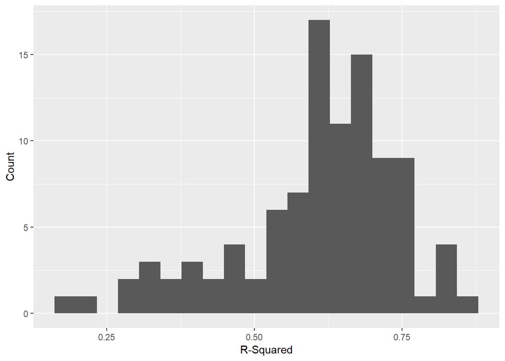

## Predicted and Observed Prices

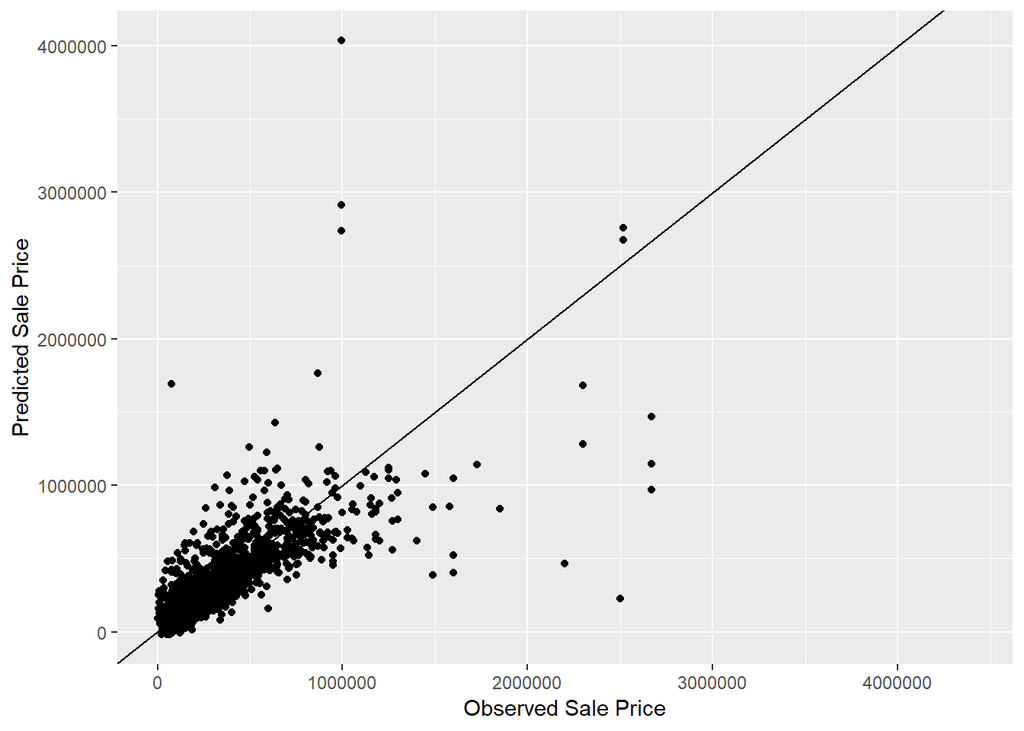

## Map of Residuals

Looking at our map of residuals can help us see if there are any geographic areas where we systematically over or under predict sales prices. If there are, this means that we have failed to include some relevant variable which is sytematically throwing off our predictions. Looking at this plot we can see that the most positive quintile of residuals, i.e. where we underpredicted by the largest amount, are clustered in the expensive neighborhood to the south-southwest. However, on the whole, most of our residuals are distributed fairly evenly, and there are no overwhelming spatial patterns to the residuals. This suggests that we accounted for most of the most glaring sources of spatial variation in sales prices.

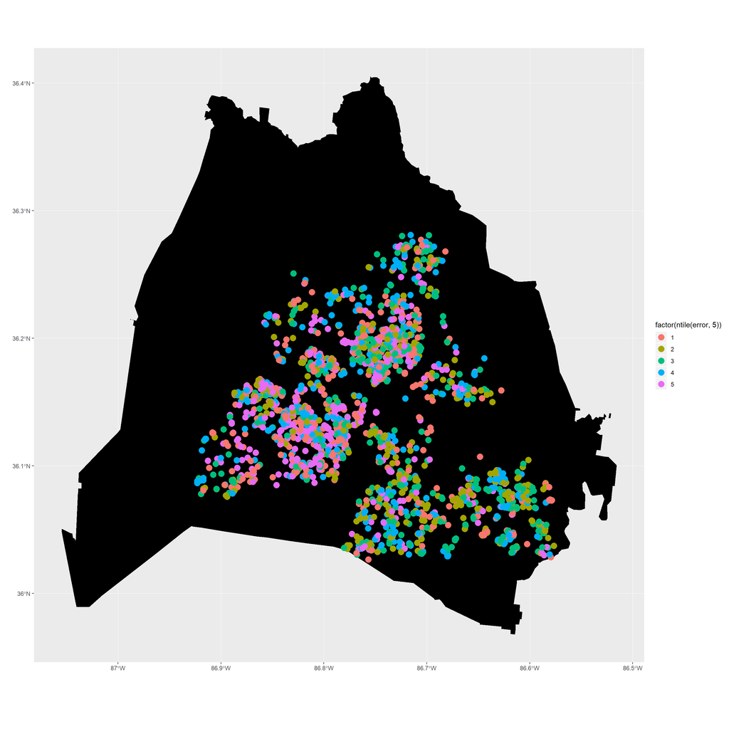

## Moran’s I

```
##
##  Moran I test under randomisation
##
## data:  testOnlyWithResiduals$error
## weights: nb2listw(spatialWeights, style = "W")
##
## Moran I statistic standard deviate = 7.049, p-value =
## 0.0000000000009008
## alternative hypothesis: greater
## sample estimates:
## Moran I statistic       Expectation          Variance
##      0.0995698647     -0.0004764173      0.0002014383
```

## Predicted Values for Entire Dataset

After all of this, we can predict values for our entire dataset. The map below shows just this, with sales divided into and colored on the basis of quintiles. Clearly the highest predicted prices are in the south-southwest while the lowest prices are in the northwest and southeast. This fits with the pattern of actual sales prices we observed in our past maps, and suggests that our predictions are largely in the ballpark.

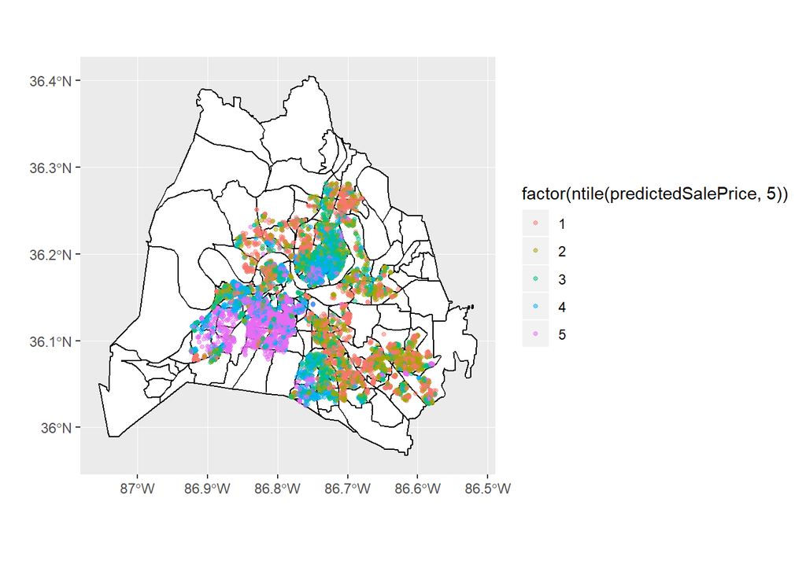

## Map of MAPE by Census Tract for Test Set Predictions

Our next map shows mean absolute percentage error (MAPE) of our predictions, aggregated to the level of the tract. Most tracts have an average MAPE of less than 1, telling us that our predictions in that tract were typically off by less than the average of price of the house sale in that tract. This is a good sign. There are, however, a couple of outliers which have MAPEs greater than 1. For these tracts, our predictions are wildly off.

Originally we intended to aggregate to the level of the Zip Code. However, we encountered technical difficulty in wrangling the Zip Code spatial data, and chose, instead, to aggregate to the level of the census tract.

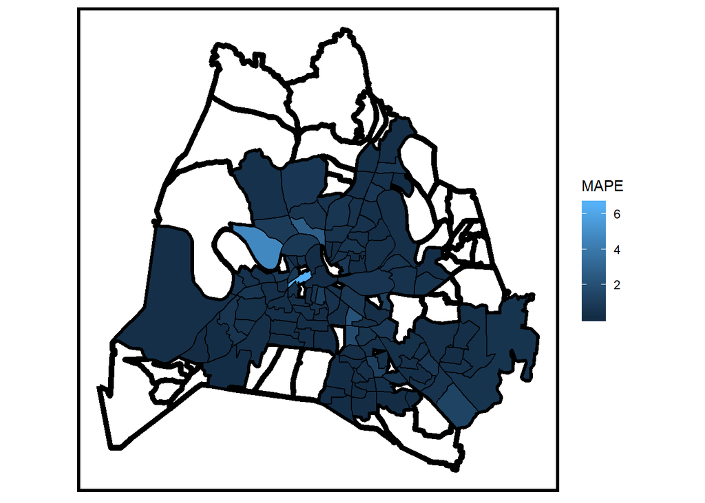

## MAPE by Census Tract as a Function of mean price

Our last plot shows the relationship between MAPE and mean sale price on the tract level. This plot shows that most tracts, with low and high mean sales prices, have MAPEs well below 1. However, it is also evident that the few tracts whose MAPEs are tremendously large outliers are concentrated among those tracts with lower mean sale prices. Given that there are far more tracts with low sales prices than high sales prices, it is difficult to tell how disproportionate this relationship truly is. This could also be due to the inherent problems in using MAPE to assess goodness of fit of predictions on both very high and very low observaed values – this problem will be discussed further in the Extra Credit section.

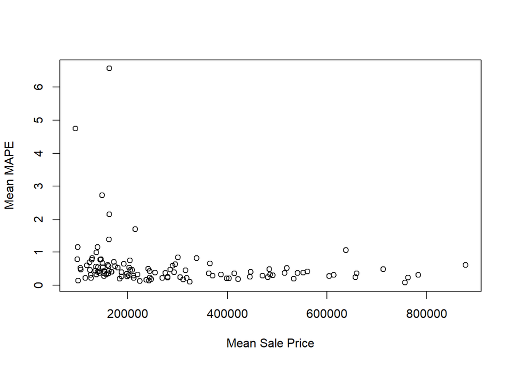

## Extra Credit: Spatial Cross-Validation on Neighborhoods of Different Socioeconomic Status

We can then test our model’s generalizability by cross-validating it specifically on neighborhoods of high, low, and medium socioeconomic status (as judged by mean sale price). If our model predicts better or worse in areas with higher or lower sales prices, this lets us know to be careful about where we apply it. When judging by two metrics of goodness of fit, MAPE and MAE, we find that our model’s efficacy does differ in areas of high vs. low sales prices. The MAE is higher when predicting sale prices in rich neighborhoods than in poor neighborhoods, with middle price neighborhoods’ MAE falling between them. Conversely, the MAPE is higher in poor neighborhoods than in rich neighborhoods, with middle price neighborhoods once again falling between them.

This apparent contradiction actually makes sense intuitively. In rich neighborhoods, prices have a much greater range than in poor neighborhoods. It is possible to see prices in a rich neighborhood range from 500 thousand to several million, creating a price range in the millions. Conversely, a poor neighborhood can only see prices fall so far, as there is a hard floor of zero. The greater price range suggests that it is reasonable to see absolute measures of error such as MAE being much greater for rich neighborhood predictions than poor neighborhoods predictions. Estimating within 100 thousand dollars of a multimillion dollar sale price is much harder than estimating within 100 thousand dollars of a hundred thousand sale price.

Conversely, it is natural for MAPE to be much higher in poor neighborhoods than in rich neighborhoods. Being off by 100 thousand on the multimillion dollar house would only marginally worsen the MAPE of that prediction, while being off by 100 thousand on the 100 thousand dollar house would increase the MAPE of that prediction to 100%. This problem is especially glaring in predicted values for several houses in the poorer neighborhood; these predicted values are below zero, which is an utterly absurd situation.

Ultimately, this suggests the limitations of using MAPE and MAE to assess goodness of fit in predictive modeling of observations iwth both very high and very low values.

The code for this section can be found in an appendix at the end.

```
##             MAPE       MAE
## Middle 0.4541567  98304.54
## Poor   0.7175849  52566.30
## Rich   0.3052807 179148.53
```

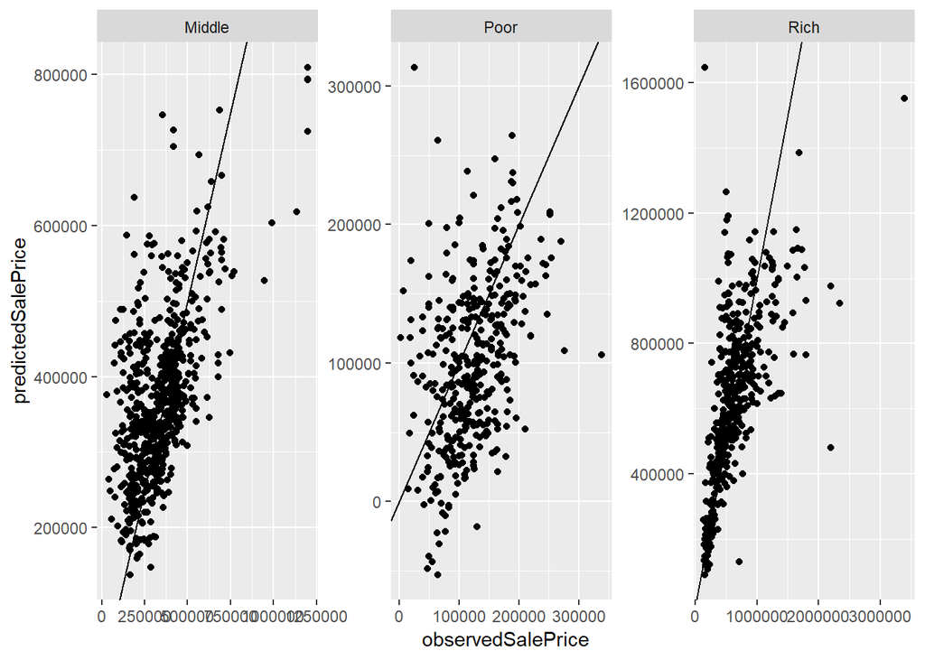

# Discussion

As far as models go, this one is fairly, but not exceptionally effective. It predicts better than a typical social-science regression, but a 100 thousand dollar MAE is nothing to write home about (or base an asking price off of) for a mean sale price of around 300 thousand dollars.

The most interesting variables were zip code (as a factor variable) and the varieties of average sale prices of nearby comparable housing units. These two sets of variables delivered far and away the largest increases in predictive power. Using zip codes as a variable largely negated the need for broad demographic variables aggregated to census tracts because, given the degee to which wealth, education, income, race, and neighborhood are intertwined, accounting for zip code largely accounts for much of this broad level variation.

# Conclusion

On the whole, we would not present this particular model to Zillow as we feel there is still much more to be improved upon. The most favorable avenue for improvement that we identify concerns the approximation of comparables. While our variables relating to the average prices of nearby sales approximated the technique of comparable comparison, we see further ways to refine these variables by adding specificity, adjusting for density of housing units, and adjusting for natural or physical barriers by which “as-the-crow-flies” determination of nearest neighbors becomes a poor method of finding the most spatially proximate comparable sales. Beyond this, we see greater potential in using spatial lag or error models, or perhaps geographically weighted regression in the place of OLS, as much of the feature engineering with regard to the comparable technique is a clumsy approximation of what could be more efficiently done in these models. Ultimately, we see this exercise as a useful learning experience in further refining our modeling attempts.

# Appendix

## Code for Extra Credit

```r
####Extra credit_______________________
trainingExceptRich <- dplyr::filter(onlyKnownData, onlyKnownData$CensusBlock != "37018601" & onlyKnownData$CensusBlock != "37018700" & onlyKnownData$CensusBlock != "37018602" & onlyKnownData$CensusBlock != "37017701" & onlyKnownData$CensusBlock != "37017702" & onlyKnownData$CensusBlock != "37018500" & onlyKnownData$CensusBlock != "37017901" & onlyKnownData$CensusBlock != "37017902" ) #the new training set
testRich <- dplyr::filter(onlyKnownData, onlyKnownData$CensusBlock == "37018601" | onlyKnownData$CensusBlock == "37018700" | onlyKnownData$CensusBlock == "37018602" | onlyKnownData$CensusBlock == "37017701" | onlyKnownData$CensusBlock == "37017702" | onlyKnownData$CensusBlock == "37018500" | onlyKnownData$CensusBlock == "37017901" | onlyKnownData$CensusBlock == "37017902" )  #the new test set
testRich <- dplyr::filter(testRich, is.na(testRich$pricePerSF) == FALSE)

trainingExceptMiddle <- dplyr::filter(onlyKnownData, onlyKnownData$CensusBlock != "37011700" & onlyKnownData$CensusBlock != "37012100" & onlyKnownData$CensusBlock != "37012200" & onlyKnownData$CensusBlock != "37011900" & onlyKnownData$CensusBlock != "37019200" & onlyKnownData$CensusBlock != "37011600") #the new training set
testMiddle <- dplyr::filter(onlyKnownData, onlyKnownData$CensusBlock == "37011700" | onlyKnownData$CensusBlock == "37012100" | onlyKnownData$CensusBlock == "37012200" | onlyKnownData$CensusBlock == "37011900" | onlyKnownData$CensusBlock == "37019200" | onlyKnownData$CensusBlock == "37011600")  #the new test set
testMiddle <- dplyr::filter(testMiddle, is.na(testMiddle$pricePerSF) == FALSE)

trainingExceptPoor <- dplyr::filter(onlyKnownData, onlyKnownData$CensusBlock != "37010903" & onlyKnownData$CensusBlock != "37010904" & onlyKnownData$CensusBlock != "37015613" & onlyKnownData$CensusBlock != "37015615" & onlyKnownData$CensusBlock != "37015617" & onlyKnownData$CensusBlock != "37015624" & onlyKnownData$CensusBlock != "37015629" & onlyKnownData$CensusBlock != "37015700"  & onlyKnownData$CensusBlock != "37015804" & onlyKnownData$CensusBlock != "37014800" & onlyKnownData$CensusBlock != "37012701" & onlyKnownData$CensusBlock != "37010701") #the new training set
testPoor <- dplyr::filter(onlyKnownData, onlyKnownData$CensusBlock == "37010903" | onlyKnownData$CensusBlock == "37010904" | onlyKnownData$CensusBlock == "37015613" | onlyKnownData$CensusBlock == "37015615" | onlyKnownData$CensusBlock == "37015617" | onlyKnownData$CensusBlock == "37015624" | onlyKnownData$CensusBlock == "37015629" | onlyKnownData$CensusBlock == "37015700" | onlyKnownData$CensusBlock == "37015804" | onlyKnownData$CensusBlock == "37014800" | onlyKnownData$CensusBlock == "37012701" | onlyKnownData$CensusBlock == "37010701" )  #the new test set
testPoor <- dplyr::filter(testPoor, is.na(testPoor$pricePerSF) == FALSE)

#Derive new model from training set
regOnRich <- lm(regFormula, data = trainingExceptRich, na.action = na.omit) #, na.action = na.omit
regOnMiddle <- lm(regFormula, data = trainingExceptMiddle, na.action = na.omit) #, na.action = na.omit
regOnPoor <- lm(regFormula, data = trainingExceptPoor, na.action = na.omit) #, na.action = na.omit

#regOnTrainPredNew <- missingLevelsToNA(regOntrain,test)  #see function defined above

#Tries out this new model on the test set
regOnRichPred <- predict(regOnRich, testRich, na.action = na.omit)
regOnMiddlePred <- predict(regOnMiddle, testMiddle, na.action = na.omit)
regOnPoorPred <- predict(regOnPoor, testPoor, na.action = na.omit)

#calculating the mean absolute error
regOnRichValues <-
  data.frame(testRich$kenID,observedSalePrice = testRich$SalePrice,
             predictedSalePrice = regOnRichPred)
regOnMiddleValues <-
  data.frame(testMiddle$kenID,observedSalePrice = testMiddle$SalePrice,
             predictedSalePrice = regOnMiddlePred)
regOnPoorValues <-
  data.frame(testPoor$kenID,observedSalePrice = testPoor$SalePrice,
             predictedSalePrice = regOnPoorPred)
regOnRichValues <-
  regOnRichValues %>%
  mutate(error = predictedSalePrice - observedSalePrice) %>%
  mutate(absError = abs(predictedSalePrice - observedSalePrice)) %>%
  mutate(percentAbsError = abs(predictedSalePrice - observedSalePrice) / observedSalePrice) %>%
  mutate(Socioeconomic_Status = "Rich") %>%
  mutate(kenID = testRich.kenID) %>%
  dplyr::select(-testRich.kenID)
regOnMiddleValues <-
  regOnMiddleValues %>%
  mutate(error = predictedSalePrice - observedSalePrice) %>%
  mutate(absError = abs(predictedSalePrice - observedSalePrice)) %>%
  mutate(percentAbsError = abs(predictedSalePrice - observedSalePrice) / observedSalePrice) %>%
  mutate(Socioeconomic_Status = "Middle") %>%
  mutate(kenID = testMiddle.kenID) %>%
  dplyr::select(-testMiddle.kenID)
regOnPoorValues <-
  regOnPoorValues %>%
  mutate(error = predictedSalePrice - observedSalePrice) %>%
  mutate(absError = abs(predictedSalePrice - observedSalePrice)) %>%
  mutate(percentAbsError = abs(predictedSalePrice - observedSalePrice) / observedSalePrice) %>%
  mutate(Socioeconomic_Status = "Poor") %>%
  mutate(kenID = testPoor.kenID) %>%
  dplyr::select(-testPoor.kenID)

regOnClassValues <- bind_rows(list(regOnRichValues,regOnMiddleValues,regOnPoorValues))

tableMAEMAPERichPoorMiddle <- matrix(c(mean(regOnMiddleValues$percentAbsError),mean(regOnMiddleValues$absError),mean(regOnPoorValues$percentAbsError),mean(regOnPoorValues$absError),mean(regOnRichValues$percentAbsError),mean(regOnRichValues$absError)),ncol=2,byrow=TRUE)
colnames(tableMAEMAPERichPoorMiddle) <- c("MAPE","MAE")
rownames(tableMAEMAPERichPoorMiddle) <- c("Middle","Poor","Rich")
tableMAEMAPERichPoorMiddle
```

```
##             MAPE       MAE
## Middle 0.4541567  98304.54
## Poor   0.7175849  52566.30
## Rich   0.3052807 179148.53
```

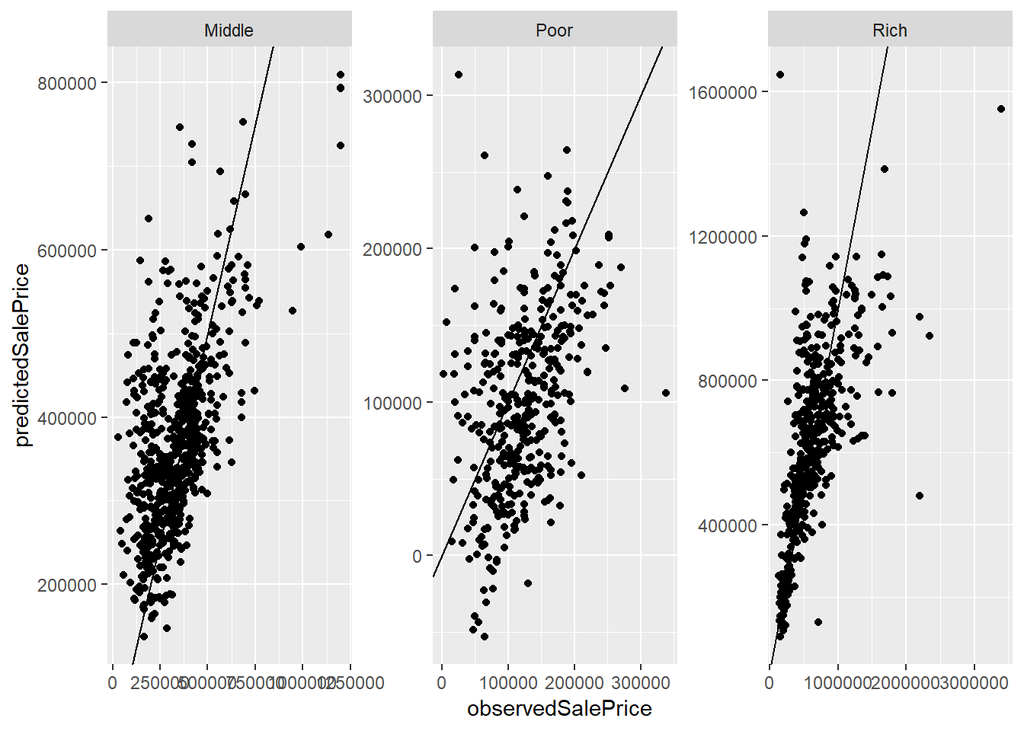

```r
ggplot(regOnClassValues, aes(x = observedSalePrice, y = predictedSalePrice)) +
  geom_point() +
  #geom_smooth(method = lm, se = FALSE) +
  geom_abline(intercept = 0, slope = 1) +
  facet_wrap( ~ Socioeconomic_Status, ncol=3, scales = "free")
```